# Extracting and visualizing tidy draws from rstanarm models

Matthew Kay

2024-09-15

## Introduction

This vignette describes how to use the `tidybayes` and `ggdist` packages to extract and visualize [tidy](https://dx.doi.org/10.18637/jss.v059.i10) data frames of draws from posterior distributions of model variables, means, and predictions from `rstanarm`. For a more general introduction to `tidybayes` and its use on general-purpose Bayesian modeling languages (like Stan and JAGS), see `vignette("tidybayes")`.

## Setup

The following libraries are required to run this vignette:

```r
library(magrittr)
library(dplyr)
library(purrr)
library(forcats)
library(tidyr)
library(modelr)
library(ggdist)
library(tidybayes)
library(ggplot2)
library(cowplot)
library(rstan)
library(rstanarm)
library(RColorBrewer)

theme_set(theme_tidybayes() + panel_border())
```

These options help Stan run faster:

```r
rstan_options(auto_write = TRUE)
options(mc.cores = parallel::detectCores())
```

## Example dataset

To demonstrate `tidybayes`, we will use a simple dataset with 10 observations from 5 conditions each:

```r
set.seed(5)
n = 10
n_condition = 5
ABC =
  tibble(
    condition = rep(c("A","B","C","D","E"), n),
    response = rnorm(n * 5, c(0,1,2,1,-1), 0.5)
  )
```

A snapshot of the data looks like this:

```r
head(ABC, 10)
```

| condition | response |
| --- | --- |
| A | -0.4204277 |
| B | 1.6921797 |
| C | 1.3722541 |
| D | 1.0350714 |
| E | -0.1442796 |
| A | -0.3014540 |
| B | 0.7639168 |
| C | 1.6823143 |
| D | 0.8571132 |
| E | -0.9309459 |

This is a typical tidy format data frame: one observation per row. Graphically:

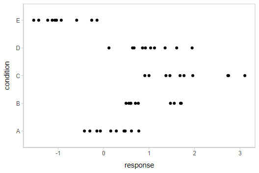

```r
ABC %>%
  ggplot(aes(y = condition, x = response)) +
  geom_point()
```

## Model

Let’s fit a hierarchical model with shrinkage towards a global mean:

```r
m = stan_lmer(response ~ (1|condition), data = ABC,
  prior = normal(0, 1, autoscale = FALSE),
  prior_aux = student_t(3, 0, 1, autoscale = FALSE),
  adapt_delta = .99)
```

The results look like this:

```r
m
```

```
## stan_lmer
##  family:       gaussian [identity]
##  formula:      response ~ (1 | condition)
##  observations: 50
## ------
##             Median MAD_SD
## (Intercept) 0.6    0.5
##
## Auxiliary parameter(s):
##       Median MAD_SD
## sigma 0.6    0.1
##
## Error terms:
##  Groups    Name        Std.Dev.
##  condition (Intercept) 1.14
##  Residual              0.56
## Num. levels: condition 5
##
## ------
## * For help interpreting the printed output see ?print.stanreg
## * For info on the priors used see ?prior_summary.stanreg
```

## Extracting draws from a fit in tidy-format using `spread_draws`

Now that we have our results, the fun begins: getting the draws out in a tidy format! First, we’ll use the `get_variables()` function to get a list of raw model variables names so that we know what variables we can extract from the model:

```r
get_variables(m)
```

```
##  [1] "(Intercept)"                              "b[(Intercept) condition:A]"
##  [3] "b[(Intercept) condition:B]"               "b[(Intercept) condition:C]"
##  [5] "b[(Intercept) condition:D]"               "b[(Intercept) condition:E]"
##  [7] "sigma"                                    "Sigma[condition:(Intercept),(Intercept)]"
##  [9] "accept_stat__"                            "stepsize__"
## [11] "treedepth__"                              "n_leapfrog__"
## [13] "divergent__"                              "energy__"
```

Here, `(Intercept)` is the global mean, and the `b` parameters are offsets from that mean for each condition. Given these parameters:

- `b[(Intercept) condition:A]`
- `b[(Intercept) condition:B]`
- `b[(Intercept) condition:C]`
- `b[(Intercept) condition:D]`
- `b[(Intercept) condition:E]`

We might want a data frame where each row is a draw from either `b[(Intercept) condition:A]`, `b[(Intercept) condition:B]`, `...:C]`, `...:D]`, or `...:E]`, and where we have columns indexing which chain/iteration/draw the row came from and which condition (`A` to `E`) it is for. That would allow us to easily compute quantities grouped by condition, or generate plots by condition using ggplot, or even merge draws with the original data to plot data and posteriors.

The workhorse of `tidybayes` is the `spread_draws()` function, which does this extraction for us. It includes a simple specification format that we can use to extract model variables and their indices into tidy-format data frames.

### Gathering variable indices into a separate column in a tidy format data frame

Given a parameter like this:

`b[(Intercept) condition:D]`

We can provide `spread_draws()` with a column specification like this:

`b[term,group]`

Where `term` corresponds to `(Intercept)` and `group` to `condition:D`. There is nothing too magical about what `spread_draws()` does with this specification: under the hood, it splits the parameter indices by commas and spaces (you can split by other characters by changing the `sep` argument). It lets you assign columns to the resulting indices in order. So `b[(Intercept) condition:D]` has indices `(Intercept)` and `condition:D`, and `spread_draws()` lets us extract these indices as columns in the resulting tidy data frame of draws from `b`:

```r
m %>%
  spread_draws(b[term,group]) %>%
  head(10)
```

| term | group | b | .chain | .iteration | .draw |
| --- | --- | --- | --- | --- | --- |
| (Intercept) | condition:A | -1.2677915 | 1 | 1 | 1 |
| (Intercept) | condition:A | -0.2132916 | 1 | 2 | 2 |
| (Intercept) | condition:A | 0.0192337 | 1 | 3 | 3 |
| (Intercept) | condition:A | -0.4226583 | 1 | 4 | 4 |
| (Intercept) | condition:A | -0.4007204 | 1 | 5 | 5 |
| (Intercept) | condition:A | 0.0275432 | 1 | 6 | 6 |
| (Intercept) | condition:A | -0.3184563 | 1 | 7 | 7 |
| (Intercept) | condition:A | -0.4145287 | 1 | 8 | 8 |
| (Intercept) | condition:A | -0.5637111 | 1 | 9 | 9 |
| (Intercept) | condition:A | -1.1462066 | 1 | 10 | 10 |

We can choose whatever names we want for the index columns; e.g.:

```r
m %>%
  spread_draws(b[t,g]) %>%
  head(10)
```

| t | g | b | .chain | .iteration | .draw |
| --- | --- | --- | --- | --- | --- |
| (Intercept) | condition:A | -1.2677915 | 1 | 1 | 1 |
| (Intercept) | condition:A | -0.2132916 | 1 | 2 | 2 |
| (Intercept) | condition:A | 0.0192337 | 1 | 3 | 3 |
| (Intercept) | condition:A | -0.4226583 | 1 | 4 | 4 |
| (Intercept) | condition:A | -0.4007204 | 1 | 5 | 5 |
| (Intercept) | condition:A | 0.0275432 | 1 | 6 | 6 |
| (Intercept) | condition:A | -0.3184563 | 1 | 7 | 7 |
| (Intercept) | condition:A | -0.4145287 | 1 | 8 | 8 |
| (Intercept) | condition:A | -0.5637111 | 1 | 9 | 9 |
| (Intercept) | condition:A | -1.1462066 | 1 | 10 | 10 |

But the more descriptive and less cryptic names from the previous example are probably preferable.

In this particular model, there is only one term (`(Intercept)`), thus we could omit that index altogether to just get each `group` and the value of `b` for the corresponding condition:

```r
m %>%
  spread_draws(b[,group]) %>%
  head(10)
```

| group | b | .chain | .iteration | .draw |
| --- | --- | --- | --- | --- |
| condition:A | -1.2677915 | 1 | 1 | 1 |
| condition:A | -0.2132916 | 1 | 2 | 2 |
| condition:A | 0.0192337 | 1 | 3 | 3 |
| condition:A | -0.4226583 | 1 | 4 | 4 |
| condition:A | -0.4007204 | 1 | 5 | 5 |
| condition:A | 0.0275432 | 1 | 6 | 6 |
| condition:A | -0.3184563 | 1 | 7 | 7 |
| condition:A | -0.4145287 | 1 | 8 | 8 |
| condition:A | -0.5637111 | 1 | 9 | 9 |
| condition:A | -1.1462066 | 1 | 10 | 10 |

Since all the groups in this case are from the `condition` factor, we may also want to separate out a column just containing the corresponding condition (`A`, `B`, `C`, etc). We can do that using `tidyr::separate`:

```r
m %>%
  spread_draws(b[,group]) %>%
  separate(group, c("group", "condition"), ":") %>%
  head(10)
```

| group | condition | b | .chain | .iteration | .draw |
| --- | --- | --- | --- | --- | --- |
| condition | A | -1.2677915 | 1 | 1 | 1 |
| condition | A | -0.2132916 | 1 | 2 | 2 |
| condition | A | 0.0192337 | 1 | 3 | 3 |
| condition | A | -0.4226583 | 1 | 4 | 4 |
| condition | A | -0.4007204 | 1 | 5 | 5 |
| condition | A | 0.0275432 | 1 | 6 | 6 |
| condition | A | -0.3184563 | 1 | 7 | 7 |
| condition | A | -0.4145287 | 1 | 8 | 8 |
| condition | A | -0.5637111 | 1 | 9 | 9 |
| condition | A | -1.1462066 | 1 | 10 | 10 |

Alternatively, we could change the `sep` argument to `spread_draws()` to also split on `:` (`sep` is a regular expression). **Note:** This works in this example, but will not work well on rstanarm models where interactions between factors are used as grouping levels in a multilevel model, thus `:` is not included in the default separators.

```r
m %>%
  spread_draws(b[,group,condition], sep = "[, :]") %>%
  head(10)
```

| group | condition | b | .chain | .iteration | .draw |
| --- | --- | --- | --- | --- | --- |
| condition | A | -1.2677915 | 1 | 1 | 1 |
| condition | A | -0.2132916 | 1 | 2 | 2 |
| condition | A | 0.0192337 | 1 | 3 | 3 |
| condition | A | -0.4226583 | 1 | 4 | 4 |
| condition | A | -0.4007204 | 1 | 5 | 5 |
| condition | A | 0.0275432 | 1 | 6 | 6 |
| condition | A | -0.3184563 | 1 | 7 | 7 |
| condition | A | -0.4145287 | 1 | 8 | 8 |
| condition | A | -0.5637111 | 1 | 9 | 9 |
| condition | A | -1.1462066 | 1 | 10 | 10 |

**Note:** If you have used `spread_draws()` with a raw sample from Stan or JAGS, you may be used to using `recover_types()` before `spread_draws()` to get index column values back (e.g. if the index was a factor). This is not necessary when using `spread_draws()` on `rstanarm` models, because those models already contain that information in their variable names. For more on `recover_types()`, see `vignette("tidybayes")`.

## Point summaries and intervals

### With simple model variables

`tidybayes` provides a family of functions for generating point summaries and intervals from draws in a tidy format. These functions follow the naming scheme `[median|mean|mode]_[qi|hdi]`, for example, `median_qi()`, `mean_qi()`, `mode_hdi()`, and so on. The first name (before the `_`) indicates the type of point summary, and the second name indicates the type of interval. `qi` yields a quantile interval (a.k.a. equi-tailed interval, central interval, or percentile interval) and `hdi` yields a highest (posterior) density interval. Custom point or interval functions can also be applied using the `point_interval()` function.

For example, we might extract the draws corresponding to the posterior distributions of the overall mean and standard deviation of observations:

```r
m %>%
  spread_draws(`(Intercept)`, sigma) %>%
  head(10)
```

| .chain | .iteration | .draw | (Intercept) | sigma |
| --- | --- | --- | --- | --- |
| 1 | 1 | 1 | 1.4707274 | 0.7488978 |
| 1 | 2 | 2 | 0.2947973 | 0.5082004 |
| 1 | 3 | 3 | 0.3301366 | 0.5640631 |
| 1 | 4 | 4 | 0.5871531 | 0.5641068 |
| 1 | 5 | 5 | 0.5221652 | 0.5328644 |
| 1 | 6 | 6 | 0.6041039 | 0.5441214 |
| 1 | 7 | 7 | 0.3356784 | 0.6227631 |
| 1 | 8 | 8 | 0.5821142 | 0.5585193 |
| 1 | 9 | 9 | 1.0652540 | 0.6601671 |
| 1 | 10 | 10 | 1.1857010 | 0.5061982 |

Like with `b[term,group]`, this gives us a tidy data frame. If we want the median and 95% quantile interval of the variables, we can apply `median_qi()`:

```r
m %>%
  spread_draws(`(Intercept)`, sigma) %>%
  median_qi(`(Intercept)`, sigma)
```

| (Intercept) | (Intercept).lower | (Intercept).upper | sigma | sigma.lower | sigma.upper | .width | .point | .interval |
| --- | --- | --- | --- | --- | --- | --- | --- | --- |
| 0.6068899 | -0.524025 | 1.576127 | 0.5602622 | 0.4564012 | 0.6969076 | 0.95 | median | qi |

We can specify the columns we want to get medians and intervals from, as above, or if we omit the list of columns, `median_qi()` will use every column that is not a grouping column or a special column (like `.chain`, `.iteration`, or `.draw`). Thus in the above example, `(Intercept)` and `sigma` are redundant arguments to `median_qi()` because they are also the only columns we gathered from the model. So we can simplify this to:

```r
m %>%
  spread_draws(`(Intercept)`, sigma) %>%
  median_qi()
```

| (Intercept) | (Intercept).lower | (Intercept).upper | sigma | sigma.lower | sigma.upper | .width | .point | .interval |
| --- | --- | --- | --- | --- | --- | --- | --- | --- |
| 0.6068899 | -0.524025 | 1.576127 | 0.5602622 | 0.4564012 | 0.6969076 | 0.95 | median | qi |

If you would rather have a long-format list of intervals, use `gather_draws()` instead:

```r
m %>%
  gather_draws(`(Intercept)`, sigma) %>%
  median_qi()
```

| .variable | .value | .lower | .upper | .width | .point | .interval |
| --- | --- | --- | --- | --- | --- | --- |
| (Intercept) | 0.6068899 | -0.5240250 | 1.5761274 | 0.95 | median | qi |
| sigma | 0.5602622 | 0.4564012 | 0.6969076 | 0.95 | median | qi |

For more on `gather_draws()`, see `vignette("tidybayes")`.

### With indexed variables

When we have a model variable with one or more indices, such as `b`, we can apply `median_qi()` (or other functions in the `point_interval()` family) as we did before:

```r
m %>%
  spread_draws(b[,group]) %>%
  median_qi()
```

| group | b | .lower | .upper | .width | .point | .interval |
| --- | --- | --- | --- | --- | --- | --- |
| condition:A | -0.4102281 | -1.4183344 | 0.7046325 | 0.95 | median | qi |
| condition:B | 0.3896187 | -0.6296754 | 1.4930599 | 0.95 | median | qi |
| condition:C | 1.2022309 | 0.2573044 | 2.3650248 | 0.95 | median | qi |
| condition:D | 0.4018216 | -0.5885280 | 1.5544478 | 0.95 | median | qi |
| condition:E | -1.4852268 | -2.5159162 | -0.3674834 | 0.95 | median | qi |

How did `median_qi()` know what to aggregate? Data frames returned by `spread_draws()` are automatically grouped by all index variables you pass to it; in this case, that means `spread_draws()` groups its results by `group`. `median_qi()` respects those groups, and calculates the point summaries and intervals within all groups. Then, because no columns were passed to `median_qi()`, it acts on the only non-special (`.`-prefixed) and non-group column, `b`. So the above shortened syntax is equivalent to this more verbose call:

```r
m %>%
  spread_draws(b[,group]) %>%
  group_by(group) %>%       # this line not necessary (done by spread_draws)
  median_qi(b)                # b is not necessary (it is the only non-group column)
```

| group | b | .lower | .upper | .width | .point | .interval |
| --- | --- | --- | --- | --- | --- | --- |
| condition:A | -0.4102281 | -1.4183344 | 0.7046325 | 0.95 | median | qi |
| condition:B | 0.3896187 | -0.6296754 | 1.4930599 | 0.95 | median | qi |
| condition:C | 1.2022309 | 0.2573044 | 2.3650248 | 0.95 | median | qi |
| condition:D | 0.4018216 | -0.5885280 | 1.5544478 | 0.95 | median | qi |
| condition:E | -1.4852268 | -2.5159162 | -0.3674834 | 0.95 | median | qi |

`tidybayes` also provides an implementation of `posterior::summarise_draws()` for grouped data frames (`tidybayes::summaries_draws.grouped_df()`), which you can use to quickly get convergence diagnostics:

```r
m %>%
  spread_draws(b[,group]) %>%
  summarise_draws()
```

| group | variable | mean | median | sd | mad | q5 | q95 | rhat | ess_bulk | ess_tail |
| --- | --- | --- | --- | --- | --- | --- | --- | --- | --- | --- |
| condition:A | b | -0.4057347 | -0.4102281 | 0.5213397 | 0.4740819 | -1.2175166 | 0.4292458 | 1.002752 | 990.7069 | 1027.350 |
| condition:B | b | 0.3957880 | 0.3896187 | 0.5212000 | 0.4695902 | -0.4213188 | 1.2533932 | 1.000767 | 1001.1480 | 1102.292 |
| condition:C | b | 1.2274826 | 1.2022309 | 0.5196388 | 0.4718675 | 0.4325652 | 2.0988210 | 1.000360 | 977.6632 | 1216.769 |
| condition:D | b | 0.4112236 | 0.4018216 | 0.5228306 | 0.4726678 | -0.4119806 | 1.2704465 | 1.001687 | 998.9768 | 1186.863 |
| condition:E | b | -1.4807896 | -1.4852268 | 0.5237237 | 0.4739114 | -2.3220879 | -0.6362849 | 1.001618 | 1010.0193 | 1154.908 |

## Combining variables with different indices in a single tidy format data frame

`spread_draws()` and `gather_draws()` support extracting variables that have different indices into the same data frame. Indices with the same name are automatically matched up, and values are duplicated as necessary to produce one row per all combination of levels of all indices. For example, we might want to calculate the mean within each condition (call this `condition_mean`). In this model, that mean is the intercept (`(Intercept)`) plus the effect for a given condition (`b`).

We can gather draws from `(Intercept)` and `b` together in a single data frame:

```r
m %>%
  spread_draws(`(Intercept)`, b[,group]) %>%
  head(10)
```

| .chain | .iteration | .draw | (Intercept) | group | b |
| --- | --- | --- | --- | --- | --- |
| 1 | 1 | 1 | 1.4707274 | condition:A | -1.2677915 |
| 1 | 1 | 1 | 1.4707274 | condition:B | -0.1775179 |
| 1 | 1 | 1 | 1.4707274 | condition:C | 0.4365900 |
| 1 | 1 | 1 | 1.4707274 | condition:D | -0.4126736 |
| 1 | 1 | 1 | 1.4707274 | condition:E | -2.1516102 |
| 1 | 2 | 2 | 0.2947973 | condition:A | -0.2132916 |
| 1 | 2 | 2 | 0.2947973 | condition:B | 0.8856697 |
| 1 | 2 | 2 | 0.2947973 | condition:C | 1.6586191 |
| 1 | 2 | 2 | 0.2947973 | condition:D | 0.7126382 |
| 1 | 2 | 2 | 0.2947973 | condition:E | -1.2611341 |

Within each draw, `(Intercept)` is repeated as necessary to correspond to every index of `b`. Thus, the `mutate` function from dplyr can be used to find their sum, `condition_mean` (which is the mean for each condition):

```r
m %>%
  spread_draws(`(Intercept)`, b[,group]) %>%
  mutate(condition_mean = `(Intercept)` + b) %>%
  median_qi(condition_mean)
```

| group | condition_mean | .lower | .upper | .width | .point | .interval |
| --- | --- | --- | --- | --- | --- | --- |
| condition:A | 0.2003063 | -0.1513986 | 0.5383789 | 0.95 | median | qi |
| condition:B | 0.9939281 | 0.6536902 | 1.3569765 | 0.95 | median | qi |
| condition:C | 1.8278779 | 1.4791869 | 2.1835717 | 0.95 | median | qi |
| condition:D | 1.0148093 | 0.6663604 | 1.3755843 | 0.95 | median | qi |
| condition:E | -0.8775708 | -1.2361596 | -0.5211076 | 0.95 | median | qi |

`median_qi()` uses tidy evaluation (see `vignette("tidy-evaluation", package = "rlang")`), so it can take column expressions, not just column names. Thus, we can simplify the above example by moving the calculation of `condition_mean` from `mutate` into `median_qi()`:

```r
m %>%
  spread_draws(`(Intercept)`, b[,group]) %>%
  median_qi(condition_mean = `(Intercept)` + b)
```

| group | condition_mean | .lower | .upper | .width | .point | .interval |
| --- | --- | --- | --- | --- | --- | --- |
| condition:A | 0.2003063 | -0.1513986 | 0.5383789 | 0.95 | median | qi |
| condition:B | 0.9939281 | 0.6536902 | 1.3569765 | 0.95 | median | qi |
| condition:C | 1.8278779 | 1.4791869 | 2.1835717 | 0.95 | median | qi |
| condition:D | 1.0148093 | 0.6663604 | 1.3755843 | 0.95 | median | qi |
| condition:E | -0.8775708 | -1.2361596 | -0.5211076 | 0.95 | median | qi |

## Plotting intervals with multiple probability levels

`median_qi()` and its sister functions can produce an arbitrary number of probability intervals by setting the `.width =` argument:

```r
m %>%
  spread_draws(`(Intercept)`, b[,group]) %>%
  median_qi(condition_mean = `(Intercept)` + b, .width = c(.95, .8, .5))
```

| group | condition_mean | .lower | .upper | .width | .point | .interval |
| --- | --- | --- | --- | --- | --- | --- |
| condition:A | 0.2003063 | -0.1513986 | 0.5383789 | 0.95 | median | qi |
| condition:B | 0.9939281 | 0.6536902 | 1.3569765 | 0.95 | median | qi |
| condition:C | 1.8278779 | 1.4791869 | 2.1835717 | 0.95 | median | qi |
| condition:D | 1.0148093 | 0.6663604 | 1.3755843 | 0.95 | median | qi |
| condition:E | -0.8775708 | -1.2361596 | -0.5211076 | 0.95 | median | qi |
| condition:A | 0.2003063 | -0.0265966 | 0.4099263 | 0.80 | median | qi |
| condition:B | 0.9939281 | 0.7693012 | 1.2269503 | 0.80 | median | qi |
| condition:C | 1.8278779 | 1.6017549 | 2.0600395 | 0.80 | median | qi |
| condition:D | 1.0148093 | 0.7787016 | 1.2419448 | 0.80 | median | qi |
| condition:E | -0.8775708 | -1.1100043 | -0.6524442 | 0.80 | median | qi |
| condition:A | 0.2003063 | 0.0841624 | 0.3098411 | 0.50 | median | qi |
| condition:B | 0.9939281 | 0.8746343 | 1.1187394 | 0.50 | median | qi |
| condition:C | 1.8278779 | 1.7088599 | 1.9502243 | 0.50 | median | qi |
| condition:D | 1.0148093 | 0.8891992 | 1.1319223 | 0.50 | median | qi |
| condition:E | -0.8775708 | -1.0004814 | -0.7593338 | 0.50 | median | qi |

The results are in a tidy format: one row per group and uncertainty interval width (`.width`). This facilitates plotting. For example, assigning `-.width` to the `linewidth` aesthetic will show all intervals, making thicker lines correspond to smaller intervals. The `ggdist::geom_pointinterval()` geom automatically sets the `linewidth` aesthetic appropriately based on the `.width` columns in the data to produce plots of points with multiple probability levels:

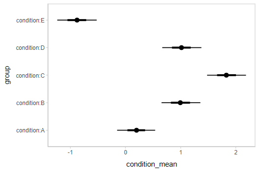

```r
m %>%
  spread_draws(`(Intercept)`, b[,group]) %>%
  median_qi(condition_mean = `(Intercept)` + b, .width = c(.95, .66)) %>%
  ggplot(aes(y = group, x = condition_mean, xmin = .lower, xmax = .upper)) +
  geom_pointinterval()
```